# Impact of Severe Weather on Communities and Municipalities

## Data Processing

The [Storm Data](https://d396qusza40orc.cloudfront.net/repdata%2Fdata%2FStormData.csv.bz2) file is downloaded if a local copy does not already exists. The `read.csv` function can directly read the `.csv` file embedded in the downloaded file.

```r
# download file (if it is necessary)
fileUrl <- "https://d396qusza40orc.cloudfront.net/repdata%2Fdata%2FStormData.csv.bz2"
localFilename <- "StormData.bz2"
if (!file.exists(localFilename)) {
    download.file(fileUrl, destfile = localFilename, mode = "wb")
}

# read the csv file embedded in the .bz2 file
StormData <- read.csv(localFilename)

# size of the imported data set
dim(StormData)
```

```
## [1] 902297     37
```

```r
# assign formats to specific columns
StormData$BGN_DATE <- as.Date(StormData$BGN_DATE, format = "%m/%d/%Y" )
StormData$EVTYPE <- as.factor(StormData$EVTYPE)
```

First, those variables that have no recorded injuries nor fatalities plus no crop or property damage are identified. This permits dropping slightly more than 70% of the data for this analyis.

Even in this subset of data, the fields are completed in a very inconsistent manner. It is the opinion of this analysis that refresher training be provided to those recording the data to encourage the data recorded in a more uniform manner. The data will become more trustworthy and require less conjecture to prepare analytic data set suitable for study.

Property and Crop damage entries with `+` or `-` in the exponent field have been imputed with an exponent of 0. Investigating the few cases where this occurs, the values for property and crop damage are probablly grossly underestimated. However as two fatalities occur in the single variable with `-` for the exponent, I prefer not to drop the variables.

```r
# tidy up parts off the data

# drop variables that have no effect (no damage, no injuries, no fatalities)
zeroPropDmg <- StormData$PROPDMG %in% 0
zeroCropDmg <- StormData$CROPDMG %in% 0
zeroFatal <- StormData$FATALITIES %in% 0
zeroInjury <- StormData$INJURIES %in% 0

zeroEffect <- (zeroPropDmg & zeroCropDmg & zeroFatal & zeroInjury)

StormData <- StormData[!zeroEffect,]

# size of the data set after dropping nonfunctional data

dim(StormData)
```

```
## [1] 254633     37
```

```r
# now cleanup the exponents

# we have these chars to cleanup in PROPDMGEXP:
#
# [1] "K" "M" ""  "B" "m" "+" "0" "5" "6" "4" "h" "2" "7" "3" "H" "-"

# we have these chars to cleanup in CROPDMGEXP:
#
# [1] ""  "M" "K" "m" "B" "?" "0" "k"

print(paste(sum(StormData$PROPDMGEXP %in% "+"), " variable with + as exponent for Property Damage"))
```

```
## [1] "5  variable with + as exponent for Property Damage"
```

```r
print(paste(sum(StormData$PROPDMGEXP %in% "-"), " variable with - as exponent for Property Damage"))
```

```
## [1] "1  variable with - as exponent for Property Damage"
```

```r
expSubs <- list(
    c("K",3),
    c("M",6),
    c("^$",0),
    c("m",6),
    c("\\?",0),
    c("h",2),
    c("H",2),
    c("B",9),
    c("k",3),
    c("[+]",0),
    c("[-]",0))

StormData$NewPROPDMGEXP <- StormData$PROPDMGEXP
StormData$NewCROPDMGEXP <- StormData$CROPDMGEXP

for (i in expSubs) {
    StormData$NewPROPDMGEXP <- gsub(i[1],i[2],StormData$NewPROPDMGEXP)
    StormData$NewCROPDMGEXP <- gsub(i[1],i[2],StormData$NewCROPDMGEXP)
}

StormData$NewPROPDMGEXP <- as.numeric(StormData$NewPROPDMGEXP)
StormData$NewCROPDMGEXP <- as.numeric(StormData$NewCROPDMGEXP)

dim(StormData)
```

```
## [1] 254633     39
```

```r
str(StormData)
```

```
## 'data.frame':    254633 obs. of  39 variables:
##  $ STATE__      : num  1 1 1 1 1 1 1 1 1 1 ...
##  $ BGN_DATE     : Date, format: "1950-04-18" "1950-04-18" ...
##  $ BGN_TIME     : Factor w/ 3608 levels "00:00:00 AM",..: 272 287 2705 1683 2584 3186 242 1683 3186 3186 ...
##  $ TIME_ZONE    : Factor w/ 22 levels "ADT","AKS","AST",..: 7 7 7 7 7 7 7 7 7 7 ...
##  $ COUNTY       : num  97 3 57 89 43 77 9 123 125 57 ...
##  $ COUNTYNAME   : Factor w/ 29601 levels "","5NM E OF MACKINAC BRIDGE TO PRESQUE ISLE LT MI",..: 13513 1873 4598 10592 4372 10094 1973 23873 24418 4598 ...
##  $ STATE        : Factor w/ 72 levels "AK","AL","AM",..: 2 2 2 2 2 2 2 2 2 2 ...
##  $ EVTYPE       : Factor w/ 985 levels "   HIGH SURF ADVISORY",..: 834 834 834 834 834 834 834 834 834 834 ...
##  $ BGN_RANGE    : num  0 0 0 0 0 0 0 0 0 0 ...
##  $ BGN_AZI      : Factor w/ 35 levels "","  N"," NW",..: 1 1 1 1 1 1 1 1 1 1 ...
##  $ BGN_LOCATI   : Factor w/ 54429 levels "","- 1 N Albion",..: 1 1 1 1 1 1 1 1 1 1 ...
##  $ END_DATE     : Factor w/ 6663 levels "","1/1/1993 0:00:00",..: 1 1 1 1 1 1 1 1 1 1 ...
##  $ END_TIME     : Factor w/ 3647 levels ""," 0900CST",..: 1 1 1 1 1 1 1 1 1 1 ...
##  $ COUNTY_END   : num  0 0 0 0 0 0 0 0 0 0 ...
```

[output cut: 25 more lines]

```r
library(plyr)
summ1 <- ddply(StormData, "EVTYPE", summarize,
               TotPropertyDamage = sum(PROPDMG * 10^NewPROPDMGEXP),
               TotCropDamage = sum(CROPDMG * 10^NewCROPDMGEXP),
               TotFatalities = sum(FATALITIES),
               TotInjuries = sum(INJURIES))
summ1$sumPropCropDamage <- summ1$TotPropertyDamage + summ1$TotCropDamage
summ1$TotPropertyDamage <- summ1$TotPropertyDamage / 1e9
summ1$TotCropDamage <- summ1$TotCropDamage / 1e9
summ1$sumPropCropDamage <- summ1$sumPropCropDamage / 1e9
head(summ1)
```

```
##                  EVTYPE TotPropertyDamage TotCropDamage TotFatalities
## 1    HIGH SURF ADVISORY           2.0e-04       0.00000             0
## 2           FLASH FLOOD           5.0e-05       0.00000             0
## 3             TSTM WIND           8.1e-03       0.00000             0
## 4       TSTM WIND (G45)           8.0e-06       0.00000             0
## 5                     ?           5.0e-06       0.00000             0
## 6   AGRICULTURAL FREEZE           0.0e+00       0.02882             0
##   TotInjuries sumPropCropDamage
## 1           0          0.000200
## 2           0          0.000050
## 3           0          0.008100
## 4           0          0.000008
## 5           0          0.000005
## 6           0          0.028820
```

## Results

### Cleveland Plots of Fatalities + Injuries vs EVTYPE:

```r
dim(summ1)
```

```
## [1] 488   6
```

```r
# zeroFatalities <- summ1$TotFatalities == 0 | is.na(summ1$TotFatalities)
# zeroInjuries <- summ1$TotInjuries == 0 | is.na(summ1$TotInjuries)
#
# sum(zeroFatalities)
# sum(!zeroFatalities)
# sum(zeroInjuries)
# sum(!zeroInjuries)
#
# unique(summ1$TotFatalities)
# unique(summ1$TotInjuries)
#
topFatalities <- order(summ1$TotFatalities, decreasing = TRUE, na.last = TRUE)
topInjuries <- order(summ1$TotInjuries, decreasing = TRUE, na.last=TRUE)
topPropDamage <- order(summ1$TotPropertyDamage, decreasing = TRUE, na.last=TRUE)
topCropDamage <- order(summ1$TotCropDamage, decreasing = TRUE, na.last=TRUE)

require(ggplot2)
require(scales)
summ1$TotFatalities[order(summ1$TotFatalities, decreasing = TRUE, na.last = TRUE)[1:25]]
```

```
##  [1] 5633 1903  978  937  816  504  470  368  248  224  206  204  172  160
## [15]  133  127  125  103  101  101   98   96   95   89   75
```

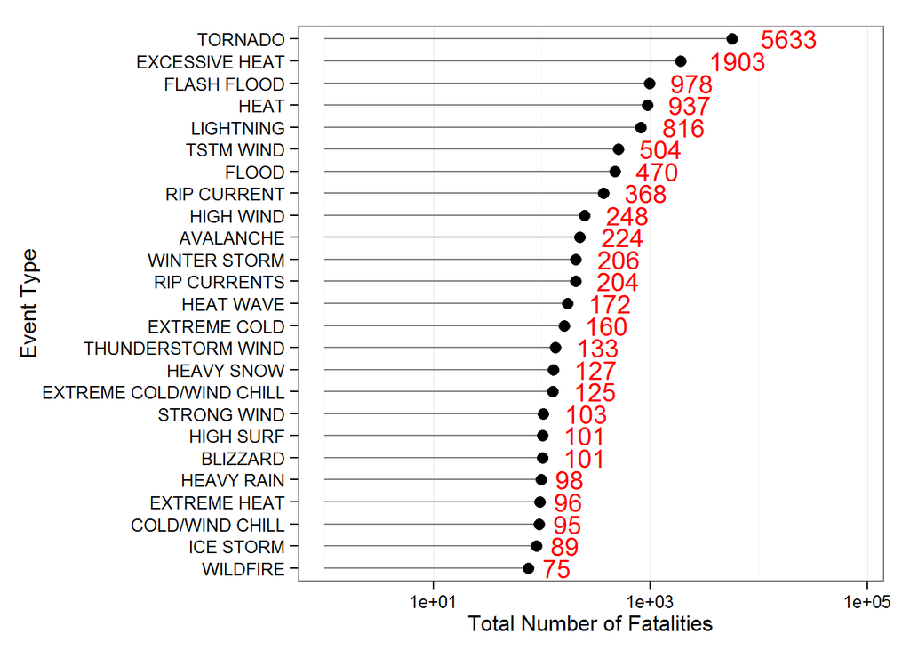

```r
topNN <-  25
p1 <- ggplot(summ1[topFatalities[1:topNN],],
             aes(x=TotFatalities, y=reorder(EVTYPE, TotFatalities))) +
    geom_segment(aes(yend=reorder(EVTYPE,TotFatalities)), xend=0, colour="grey50") +
    geom_point(size=3) +
    theme_bw() +
    theme(panel.grid.major.y = element_blank()) +
    geom_text(aes(label=TotFatalities), hjust=-0.5, colour="red")
p1 <-p1 + xlab("Total Number of Fatalities") +
    ylab("Event Type")
p1 + scale_x_log10(limits=c(1,80000))
```

```r
summ1$TotInjuries[order(summ1$TotInjuries, decreasing = TRUE, na.last=TRUE)[1:25]]
```

```
##  [1] 91346  6957  6789  6525  5230  2100  1975  1777  1488  1361  1321
## [12]  1275  1137  1021   911   908   805   734   545   440   398   342
## [23]   340   309   302
```

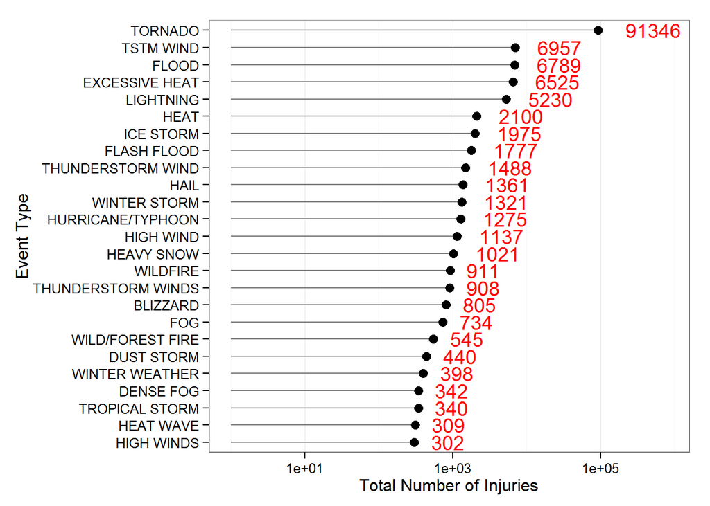

```r
p2 <- ggplot(summ1[topInjuries[1:topNN],],
             aes(x=TotInjuries, y=reorder(EVTYPE, TotInjuries))) +
    geom_segment(aes(yend=reorder(EVTYPE,TotInjuries)), xend=0, colour="grey50") +
    geom_point(size=3) +
    theme_bw() +
    theme(panel.grid.major.y = element_blank()) +
    geom_text(aes(label=TotInjuries), hjust=-0.5, colour="red")
p2 <- p2 + xlab("Total Number of Injuries") +
    ylab("Event Type")
p2 + scale_x_log10(limits=c(1,800000))
```

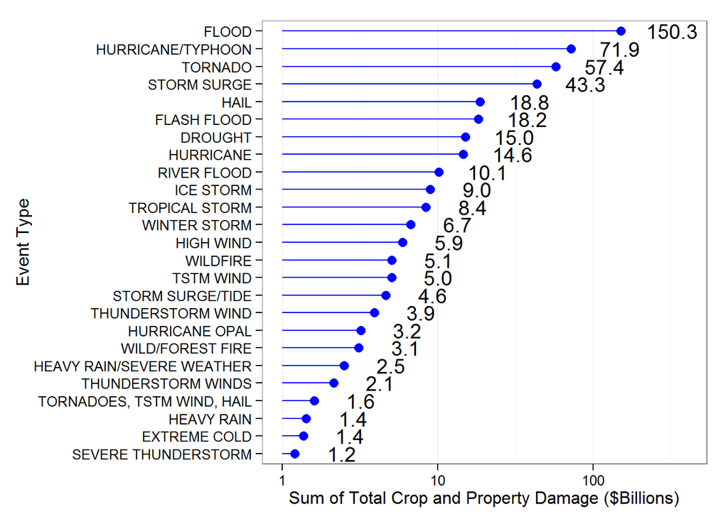

```r
topCPDamage <- order(summ1$sumPropCropDamage, decreasing = TRUE)
p5 <- ggplot(summ1[topCPDamage[1:topNN],],
             aes(x=sumPropCropDamage, y=reorder(EVTYPE, sumPropCropDamage))) +
    geom_segment(aes(yend=reorder(EVTYPE,sumPropCropDamage)), xend=0, colour="blue") +
    geom_point(size=3, color="blue") +
    geom_text(aes(label=format(sumPropCropDamage, digits=2), hjust=-0.5))

p5 <- p5 + theme_bw() + theme(panel.grid.major.y = element_blank()) +
    xlab("Sum of Total Crop and Property Damage ($Billions)") +
    ylab("Event Type")

p5 + scale_x_log10(limits=c(1,400))
```